# — 1. Setup —

## 1.1 Load Libraries

```r
# Define the list of packages
my_packages <- c(
## Data loading, cleaning, manipulation
"tidyverse", "dplyr", "data.table", "arrow", "purrr", "visdat",

## Visualization
"ggplot2", "ggrepel", "ggdist", "gghalves", "patchwork",
"ComplexHeatmap", "circlize", "dendextend",

## Descriptive statistics and summaries
"table1",

## Modeling and statistics
"reshape2", "fixest", "tictoc", "lme4", "lmerTest",
"broom.mixed", "effectsize", "modelsummary", "multcomp"
)

# Install any missing packages
installed_packages <- rownames(installed.packages())
missing_packages <- my_packages[!my_packages %in% installed_packages]
if(length(missing_packages) > 0) install.packages(missing_packages)

# Load the libraries and store the results (TRUE for success, FALSE for failure)
loaded <- sapply(my_packages, require, character.only = TRUE)
cat("✅ Package loading summary:\n")
```

```
## ✅ Package loading summary:
```

```r
loaded_df <- data.frame(Package = names(loaded), Loaded = loaded)
print(loaded_df)
```

```
##                       Package Loaded
## tidyverse           tidyverse   TRUE
## dplyr                   dplyr   TRUE
## data.table         data.table   TRUE
## arrow                   arrow   TRUE
## purrr                   purrr   TRUE
## visdat                 visdat   TRUE
## ggplot2               ggplot2   TRUE
## ggrepel               ggrepel   TRUE
## ggdist                 ggdist   TRUE
## gghalves             gghalves   TRUE
## patchwork           patchwork   TRUE
## ComplexHeatmap ComplexHeatmap   TRUE
## circlize             circlize   TRUE
## dendextend         dendextend   TRUE
## table1                 table1   TRUE
## reshape2             reshape2   TRUE
## fixest                 fixest   TRUE
## tictoc                 tictoc   TRUE
## lme4                     lme4   TRUE
## lmerTest             lmerTest   TRUE
## broom.mixed       broom.mixed   TRUE
## effectsize         effectsize   TRUE
## modelsummary     modelsummary   TRUE
## multcomp             multcomp   TRUE
```

# — 2. Data Preparation —

## 2.1 Loading and Merging Main Datasets

This section loads the core metrics datasets (post-level and topic-level) and the corresponding raw content data (post content and topic content/prompts). It then performs an initial merge to combine the metrics with the clean content for each level.

Two levels of dataset: The post-level dataset contains individual student posts, while the topic-level dataset aggregates each discussion topic’s overall content creation and social engagement indicators.

```r
# Load core metrics datasets: the datasets with metrics measuring content creation and social engagement.
df_topic_metrics <- read.csv("data/df_topic_0904.csv")
df_post_metrics <- read.csv("data/df_post_0904.csv")
cat("✅ Loaded post-level and topic-level metrics data (CSV).\n")
```

```
## ✅ Loaded post-level and topic-level metrics data (CSV).
```

```r
# Load content data (for both topics and posts): Topic content is discussion prompts, while post content is each individual post under discussion topics.
## Topic content: only select the discussion topics for which we have topic metrics.
topic_content <- read_parquet("data/discussion_topic_assignment_19_24_cleaned_content_only.parquet.gzip")
topic_content <- topic_content%>%subset(discussion_topic_id%in%df_topic_metrics$discussion_topic_id)

## Post content: only select the discussion posts for which we have post metrics.
post_content <- read_parquet("data/discussion_post_assignment_19_24_cleaned_content_only.parquet.gzip")
post_content <- post_content%>%subset(discussion_post_id%in%df_post_metrics$discussion_post_id)
cat("✅ Loaded and filtered topic and post content data (Parquet).\n")
```

```
## ✅ Loaded and filtered topic and post content data (Parquet).
```

```r
# Merge content data with metrics data: connect discussion prompts and posts with metrics
## df_post: Post metrics joined with clean post content.
df_post <- left_join(df_post_metrics, post_content, by = "discussion_post_id")

## df_topic: Topic metrics joined with clean discussion topic prompt content.
df_topic <- left_join(df_topic_metrics, topic_content, by = "discussion_topic_id")
cat("✅ Merging complete. Created df_post and df_topic.\n")
```

```
## ✅ Merging complete. Created df_post and df_topic.
```

## 2.2 Initial Data Inspection

```r
# Calculate percentage of missing values per column in df_topic
cat("--- Missing Value Percentage in df_topic: !!! Rows with missing 'discussion_topic_content_clean' will be removed later for modeling ---\n")
```

```
## --- Missing Value Percentage in df_topic: !!! Rows with missing 'discussion_topic_content_clean' will be removed later for modeling ---
```

```r
# Define the common text representations of missing values you want to exclude
missing_content_placeholders <- c("", "NA", "N/A", "NULL", "No message")

# Enhanced check for all forms of missingness in the key content column
total_missing_count <- sum(
  is.na(df_topic$discussion_topic_content_clean) |
  df_topic$discussion_topic_content_clean %in% missing_content_placeholders
)
total_missing_percentage <- (total_missing_count / nrow(df_topic)) * 100

cat("--- Enhanced Missing Value Percentage in df_topic ---\n")
```

```
## --- Enhanced Missing Value Percentage in df_topic ---
```

```r
cat("Total rows (topics):", nrow(df_topic), "\n")
```

```
## Total rows (topics): 7667
```

```r
cat(sprintf("Total missing/empty/placeholder content rows (Count): %d\n", total_missing_count))
```

```
## Total missing/empty/placeholder content rows (Count): 432
```

```r
cat(sprintf("Total missing/empty/placeholder content rows (Percentage): %.2f%%\n", total_missing_percentage))
```

```
## Total missing/empty/placeholder content rows (Percentage): 5.63%
```

```r
# Count the number of unique values (check duplicates) for each variable in df_topic
cat("--- Unique Value Count in df_topic ---\n")
```

```
## --- Unique Value Count in df_topic ---
```

```r
df_topic_unique_counts <- df_topic %>%
  summarise(across(everything(), n_distinct))
print(df_topic_unique_counts)
```

```
##      X discussion_topic_id avg_similarity embedding_variance semantic_spread
## 1 7667                7667           7662               7663             353
##   MRS_depth thread_MRS_avg_depth post_count max_depth avg_depth max_width
## 1      6392                 1900        333         5      1247        36
##   avg_width total_users replied_users percent_replied avg_top_post_length
## 1      1245         214           118             958                5165
##   discussion_topic_title discussion_topic_content_clean
## 1                   4810                            909
```

```r
cat("Note: With 7667 topic IDs, having 909 unique content entries confirms many topics reuse the same discussion prompt.\n")
```

```
## Note: With 7667 topic IDs, having 909 unique content entries confirms many topics reuse the same discussion prompt.
```

```r
# ---Inspecting df_post: get a sense of variables in df_post that might be useful--
# Calculate percentage of missing values per column in df_post
cat("--- Missing Value Percentage in df_post ---\n")
```

```
## --- Missing Value Percentage in df_post ---
```

```r
na_percentage_post <- colSums(is.na(df_post)) / nrow(df_post) * 100
print(na_percentage_post[na_percentage_post > 0])
```

```
##         parent_discussion_post_id                     user_group_id
##                        54.8608849                        49.8264595
##                  first_generation                              race
##                         7.2504665                         3.8248924
##                            gender                         term_code
##                         0.3381953                         3.4131880
##                      course_title                       school_code
##                         3.4131880                       100.0000000
##                school_name_abbrev                         dept_code
##                       100.0000000                       100.0000000
##                  dept_name_abbrev                      course_level
##                         3.4131880                       100.0000000
##                       course_type                     online_course
##                         3.4131880                       100.0000000
##                            uptake parent_discussion_post_created_at
##                        56.0076794                        56.0752646
##                 response_time_gap
##                        56.0752646
```

```r
cat("Note: 1. These variables have no data: school_code, school_name_abbrev, dept_code, course_level, online_course. 2. The variables(50–57% na_values) primarily related to post interaction/response have missing values structurally induced by the post_type: parent_discussion_post_id, uptake, parent_discussion_post_created_at, response_time_gap, user_group_id. 3. Variable with low missingness (< 8%): first_generation, race, dept_name_abbrev, term_code, course_title, course_type, gender.\n")
```

[output not shown]

```r
cat("---!!! Need to handle missing values in course_type and dept_name_abbrev---\n")
```

```
## ---!!! Need to handle missing values in course_type and dept_name_abbrev---
```

```r
# Count the number of unique values for each variable in df_post
cat("\n--- Unique Value Count in df_post ---\n")
```

```
##
## --- Unique Value Count in df_post ---
```

```r
df_post_unique_counts <- df_post %>%
  summarise(across(everything(), n_distinct))
print(df_post_unique_counts)
```

```
##      X.1      X mellon_id canvas_course_id discussion_post_id
## 1 371383 371383     26474              746             371383
##   parent_discussion_post_id discussion_post_created_at
## 1                     91914                     368113
##   discussion_topic_posted_at discussion_topic_id user_group_id gpa_term
## 1                       3389                7667          1081      333
##   Analytic Clout Tone Authentic int_student citizenship_app first_generation
## 1     8560  8964 7119      8360           2               4                3
##   low_income first_language race gender term class_size term_code course_title
## 1          3             31    6      3    8        180         9          196
##   school_code school_name_abbrev dept_code dept_name_abbrev course_level
## 1           1                  1         1               53            1
##   course_type online_course informativeness politeness uptake formality
## 1          10             1           53674        460 153498    366046
##   word_cnt parent_discussion_post_created_at post_time_gap response_time_gap
## 1     1444                             89147        351511            162193
##   first_post_created_at post_type GPT discussion_post_content_clean
## 1                  7665         2   2                        370881
```

# —Research Question —

RQ1: At the discussion topic level, how do students’ content creation and social engagement differ between cases where GPT use = 0 (no GenAI) and GPT use = 1 (GenAI used) Build formula with course-level controls + fixed effects for the full dataset formula <- as.formula( paste0(metric, ” ~ GPT_use + discussion_size_s + pct_international_s + pct_posts_s + course_type | discussion_topic_content_clean”)) RQ2: How do these impacts vary across different majors? Same formula as RQ1, but it will run through each field’s subset RQ3: How do these impacts vary across different discussion prompt types? Same formula as RQ1, but it will run through each discussion prompt’s subset

—Summary of key variables for next steps — Core Identifiers and Key Variables - ID: mellon_id (Student ID), discussion_topic_id (Grouping ID for aggregation: used to merge post-level and topic-level data) - Independent variable: GPT (0=No GPT time, 1=GPT time) - Post Metrics: Analytic, informativeness, word_cnt (These will be averaged per topic)

Control Variables - discussion_size: Number of unique students (mellon_id) within each discussion_topic_id → Calculate using df_post %>% group_by(discussion_topic_id) %>% summarise(discussion_size = n_distinct(mellon_id)) - course_type: Type of course (e.g., lecture, seminar) - int_student: Percentage of international students within each discussion topic → Calculate as mean(int_student == 1) per discussion_topic_id - post_type_ratio: Proportion of original posts relative to total posts (posts + replies) → pct_posts = number_of_posts / (number_of_posts + number_of_replies)

RQ2 dept_name_abbrev: will be used to subset fields

—All variables (for reference only) — - Content: discussion_post_content_clean - Course context variables: dept_name_abbrev, class_size, course_type, term, course_title - Identifiers: canvas_course_id, discussion_post_id, parent_discussion_post_id, , user_group_id, - Time-based variables: discussion_post_created_at, discussion_topic_posted_at, parent_discussion_post_created_at - Academic: gpa_term - Demographic Variables: int_student, citizenship_app, first_generation, low_income, first_language, race, gender. - Interaction: post_type, post_time_gap, response_time_gap, uptake, first_post_created_at - Content tone: Clout, Authentic, Tone, politeness, formality

## 2.3 Data Aggregation: Post-level to Topic-level

```r
# Create topic-level aggregated variables from post-level data
topic_aggregated <- df_post %>%
  group_by(discussion_topic_id) %>%
  summarise(
    # Student and discussion characteristics
    discussion_size = n_distinct(mellon_id),
    pct_international = mean(int_student, na.rm = TRUE) * 100,

    # Percentage of Original Posts: The count of "Post" type contributions divided by the total count of "Post" and "Reply" types.
    pct_posts = 100 * sum(post_type == "Post", na.rm = TRUE) /
                        (sum(post_type == "Post", na.rm = TRUE) + sum(post_type == "Reply", na.rm = TRUE)),

    # Content measures - averages per topic: Averaged measures of content length, depth, and width.
    avg_word_count = mean(word_cnt, na.rm = TRUE),
    avg_analytic = mean(Analytic, na.rm = TRUE),
    avg_informativeness = mean(informativeness, na.rm = TRUE),

    # GPT usage indicators
    GPT_use = as.numeric(any(GPT == 1, na.rm = TRUE)),

    # Course characteristics (taking first value since should be constant within topic).
    ## While course_type and dept_name_abbrev have missing values, we will handle that later in df_combined just in case some miss values for certain rows can be found in others with the same topic_id.
    #class_size = first(class_size), # this is not necessary
    course_type = first(course_type),
    dept_name_abbrev = first(dept_name_abbrev),

    .groups = 'drop' # Important: Removes the grouping structure after summarization
  )
cat("✅ Successfully aggregated post-level data into 'topic_aggregated' dataframe.\n")
```

```
## ✅ Successfully aggregated post-level data into 'topic_aggregated' dataframe.
```

```r
# Merge aggregated post-level metrics with topic-level data
df_combined <- left_join(topic_aggregated, df_topic, by = "discussion_topic_id")
cat("✅ Merged 'topic_aggregated' with 'df_topic'. The final analytical dataset is 'df_combined'.\n")
```

```
## ✅ Merged 'topic_aggregated' with 'df_topic'. The final analytical dataset is 'df_combined'.
```

```r
cat(paste("Final Combined Dataset ('df_combined') has", nrow(df_combined), "rows (topics).\n"))
```

```
## Final Combined Dataset ('df_combined') has 7667 rows (topics).
```

## 2.4 Check Core Metrics

```r
# Define content creation indicators
content_metrics <- c(
  "avg_similarity", "embedding_variance", "semantic_spread",
  "MRS_depth","avg_word_count","avg_analytic", "avg_informativeness"
)
# Define social engagement indicators
social_metrics <- c(
  "percent_replied", "avg_depth", "max_depth",
  "avg_width", "max_width"
)

# Combine into one master list
all_metrics <- c(content_metrics, social_metrics)
cat("✅ Content and Social Metrics lists defined.\n")
```

```
## ✅ Content and Social Metrics lists defined.
```

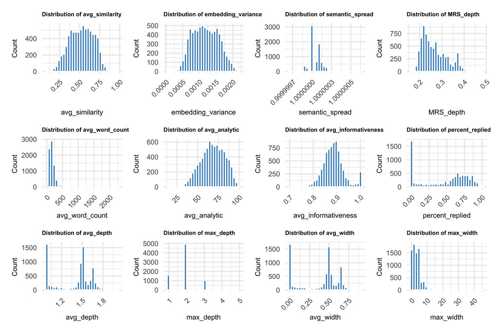

```r
# Create a list of histogram plots
plot_list <- map(all_metrics, ~{
  ggplot(df_combined, aes(x = .data[[.x]])) +
    geom_histogram(bins = 30, fill = "#0072B2", color = "white", alpha = 0.8) +
    labs(
      title = paste("Distribution of", .x),
      x = .x,
      y = "Count"
    ) +
    theme_minimal(base_size = 10) +
    theme(
      plot.title = element_text(size = 5, face = "bold"),
      axis.title.x = element_text(size = 6), axis.title.y = element_text(size = 6),
      axis.text.x = element_text(angle = 45, hjust = 1, size = 6), axis.text.y = element_text(size = 6)
    )
})
# Combine and display the plots using patchwork
# We will arrange them into 3 rows of 4 columns for a compact view.
combined_plot <- wrap_plots(plot_list, ncol = 4, nrow = 3)

# Print the combined plot
print(combined_plot)
```

```r
cat("--- Summary Statistics for Key Metrics in df_combined ---\n")
```

```
## --- Summary Statistics for Key Metrics in df_combined ---
```

```r
# Use 'all_of()' inside select to explicitly handle character vector of column names
# Use unclass() or as.data.frame() before print() to ensure the 'n' argument works
df_combined_summary <- df_combined %>%
  dplyr::select(all_of(all_metrics)) %>%
  pivot_longer(cols = everything(), names_to = "metric", values_to = "value") %>%
  group_by(metric) %>%
  summarise(
    Mean = mean(value, na.rm = TRUE),
    SD = sd(value, na.rm = TRUE),
    Min = min(value, na.rm = TRUE),
    Max = max(value, na.rm = TRUE),
    Q99 = quantile(value, 0.99, na.rm = TRUE), # Check 99th percentile for outliers
    .groups = 'drop'
  )

# Convert to a standard data frame and print the result
print(df_combined_summary, n = 12)
```

```
## # A tibble: 12 × 6
##    metric                   Mean      SD        Min        Max       Q99
##    <chr>                   <dbl>   <dbl>      <dbl>      <dbl>     <dbl>
##  1 MRS_depth             0.266   5.43e-2  0.168        0.484     0.393
##  2 avg_analytic         68.2     1.41e+1 13.4         98.4      94.5
##  3 avg_depth             1.39    2.54e-1  1            2.02      1.79
##  4 avg_informativeness   0.886   4.39e-2  0.701        1         1
##  5 avg_similarity        0.525   1.46e-1  0.0876       0.966     0.806
##  6 avg_width             0.383   2.50e-1  0            0.9       0.754
##  7 avg_word_count      178.      1.36e+2 11.1       2251.      763.
##  8 embedding_variance    0.00119 3.79e-4  0.0000824    0.00219   0.00199
##  9 max_depth             1.94    6.07e-1  1            5         3
## 10 max_width             3.11    3.20e+0  0           45        15
## 11 percent_replied       0.471   3.27e-1  0            1         0.938
## 12 semantic_spread       1.00    7.59e-8  1.000        1.00      1.00
```

```r
# # Apply CONSTANT MANUAL SCALING to specific metrics
# df_combined <- df_combined %>%
#   mutate(
#     # 1. Scale avg_word_count: Divide by 1000 (New unit: thousands of words)
#     avg_word_count = avg_word_count / 1000,
#     # 2. Scale avg_analytic: Divide by 100 (New unit: hundredths of LIWC score)
#     # The max raw value is ~98, so the max scaled value will be ~0.98.
#     avg_analytic = avg_analytic / 100,
#     # 3. Scale max_width: Divide by 10 (New unit: tenths of post count)
#     # The max raw value is 45, so the max scaled value will be 4.5.
#     # max_width = max_width / 10
#  )
# Apply z-score standardization to all metrics
df_combined <- df_combined %>%
  mutate(across(all_of(all_metrics), ~scale(.)[,1]))
```

## 2.5: Cleaning and Recoding for Analysis

```r
# Check missing values in the intermediate combined dataset
cat("--- Missing Value Count in df_combined (Before Cleaning) ---\n")
```

```
## --- Missing Value Count in df_combined (Before Cleaning) ---
```

```r
na_df_combined <- colSums(is.na(df_combined))
print(na_df_combined[na_df_combined > 0])
```

```
##                    course_type               dept_name_abbrev
##                            264                            264
## discussion_topic_content_clean
##                            392
```

```r
cat("Note: Proceeding to clean missing values.\n")
```

```
## Note: Proceeding to clean missing values.
```

```r
# Handle missing values
df_analysis <- df_combined %>%
  # remove rows where discussion_topic_content_clean is NA
  filter(
    # Exclude standard NA values
    !is.na(discussion_topic_content_clean) &
    # Exclude text placeholders/empty strings
    !(discussion_topic_content_clean %in% missing_content_placeholders)) %>%

  mutate(
    dept_name_abbrev = ifelse(is.na(dept_name_abbrev), "Unknown", dept_name_abbrev),
    course_type      = ifelse(is.na(course_type), "Unknown", course_type)
  )
cat("✅ Rows remaining after filtering NA topic content:", nrow(df_analysis), "\n")
```

```
## ✅ Rows remaining after filtering NA topic content: 7235
```

```r
cat("--- Missing Value Count in df_analysis (After Cleaning) ---\n")
```

```
## --- Missing Value Count in df_analysis (After Cleaning) ---
```

```r
colSums_na_df_analysis <- colSums(is.na(df_analysis))
print(colSums_na_df_analysis[colSums_na_df_analysis > 0])
```

```
## named numeric(0)
```

```r
# Should show no NAs for key variables
```

## 2.6 Factorize and Standardize Variables

```r
# Convert categorical variables to factors and Standardize numeric variables (z-score) for modeling or comparison
df_analysis_transformed <- df_analysis %>%
  mutate(
    # Factorize categorical variables
    course_type = as.factor(course_type),
    discussion_topic_content_clean = as.factor(discussion_topic_content_clean),
    # Standardize continuous control variables (Z-score)
    discussion_size = scale(discussion_size)[,1],
    pct_international = scale(pct_international)[,1],
    pct_posts = scale(pct_posts)[,1]

  )
head(df_analysis_transformed)
```

```
## # A tibble: 6 × 27
##   discussion_topic_id discussion_size pct_international pct_posts avg_word_count
##                 <int>           <dbl>             <dbl>     <dbl>          <dbl>
## 1              593148           0.844             0.221      1.64        -0.325
## 2              593152           3.54             -0.243      1.59        -0.283
## 3              593154           3.34             -0.236      1.62         0.0721
## 4              593155           0.844             0.183      1.51        -0.209
## 5              596691          -0.268             0.169      1.64         0.0627
## 6              596692          -0.323             0.299      1.64         0.0544
## # ℹ 22 more variables: avg_analytic <dbl>, avg_informativeness <dbl>,
## #   GPT_use <dbl>, course_type <fct>, dept_name_abbrev <chr>, X <int>,
## #   avg_similarity <dbl>, embedding_variance <dbl>, semantic_spread <dbl>,
## #   MRS_depth <dbl>, thread_MRS_avg_depth <dbl>, post_count <int>,
## #   max_depth <dbl>, avg_depth <dbl>, max_width <dbl>, avg_width <dbl>,
## #   total_users <int>, replied_users <int>, percent_replied <dbl>,
## #   avg_top_post_length <dbl>, discussion_topic_title <chr>, …
```

```r
cat("✅ Created 'df_analysis_field_transformed': Categorical variables factorized and controls standardized.\n")
```

```
## ✅ Created 'df_analysis_field_transformed': Categorical variables factorized and controls standardized.
```

```r
cat(paste("Final Analytical Dataset ('df_analysis_field_transformed') has", nrow(df_analysis_transformed), "rows.\n"))
```

```
## Final Analytical Dataset ('df_analysis_field_transformed') has 7235 rows.
```

```r
# Only factorize variables
df_analysis_factorized <- df_analysis %>%
  mutate(
    course_type = as.factor(course_type),
    discussion_topic_content_clean = as.factor(discussion_topic_content_clean),
  )
head(df_analysis_factorized)
```

```
## # A tibble: 6 × 27
##   discussion_topic_id discussion_size pct_international pct_posts avg_word_count
##                 <int>           <int>             <dbl>     <dbl>          <dbl>
## 1              593148              59              22.0     100          -0.325
## 2              593152             156              13.2      98.7        -0.283
## 3              593154             149              13.3      99.3         0.0721
## 4              593155              59              21.3      96.7        -0.209
## 5              596691              19              21.1     100           0.0627
## 6              596692              17              23.5     100           0.0544
## # ℹ 22 more variables: avg_analytic <dbl>, avg_informativeness <dbl>,
## #   GPT_use <dbl>, course_type <fct>, dept_name_abbrev <chr>, X <int>,
## #   avg_similarity <dbl>, embedding_variance <dbl>, semantic_spread <dbl>,
## #   MRS_depth <dbl>, thread_MRS_avg_depth <dbl>, post_count <int>,
## #   max_depth <dbl>, avg_depth <dbl>, max_width <dbl>, avg_width <dbl>,
## #   total_users <int>, replied_users <int>, percent_replied <dbl>,
## #   avg_top_post_length <dbl>, discussion_topic_title <chr>, …
```

## 2.7 Dataset for RQ2 (Grouping Departments)

This step creates the field variable needed to subset the data for RQ2.

```r
# Inspect Unique Departments
unique_dept <- unique(df_analysis$dept_name_abbrev)
cat("departments:", unique_dept, "\n")
```

[output not shown]

```r
# Create 'field' Variables: Language, Art, Humanities, Social Science, Theoretical STEM, Applied STEM, Others
df_analysis_field <- df_analysis_factorized %>%
  mutate(field = case_when(
    dept_name_abbrev %in% c("FRENCH","ENGLISH","GERMAN","ARABIC","SPANISH", "ACENG") ~ "Language",
    dept_name_abbrev %in% c("MUSIC","ART","DRAMA","DANCE") ~ "Arts",
    dept_name_abbrev %in% c("COMLIT","FLM&MDA","WRITING","PHILOS","HISTORY",
                            "ASIANAM","EAS","HUMAN") ~ "Humanities",
    dept_name_abbrev %in% c("CHC/LAT","SOCSCI","CRM/LAW","ANTHRO","ECON","PSCI",
                            "SOCIOL","POLSCI","SOCECOL","UPPP","INTLST","LSCI",
                            "PSYCH","SPPS","MGMT","EDUC") ~ "Social Sciences",
    dept_name_abbrev %in% c("PHYSICS","EARTHSS","MATH","BIOSCI") ~ "Theoretical STEM",
    dept_name_abbrev %in% c("COMPSCI","I&CSCI","IN4MATX","ENGR","ENGRMAE",
                            "PHRMSCI","PUBHLTH","NURSCI") ~ "Applied STEM",
    dept_name_abbrev %in% c("UNIAFF","UNISTU") ~ "Others",
    TRUE ~ "Unknown"   # catch-all for missing or uncategorized departments
  ))
cat("✅ Created field classification variable 'field'.\n")
```

```
## ✅ Created field classification variable 'field'.
```

```r
df_analysis_field <- df_analysis_field %>%
  mutate(field = as.factor(field))

# Split the data frame dept_name_abbrev into a list of data frames.
field_subsets_all <- split(df_analysis_field, df_analysis_field$field)

# Will drop Unknown and Others field subset from this list
field_subsets <- field_subsets_all[names(field_subsets_all) != "Unknown" & names(field_subsets_all) != "Others"]

# To view the names of all the created subsets:
cat("Subset Names (for iteration in regression):", names(field_subsets),"\n")
```

```
## Subset Names (for iteration in regression): Applied STEM Arts Humanities Language Social Sciences Theoretical STEM
```

```r
# Confirming the names of the subsets created
cat("✅ Data successfully split into", length(field_subsets), "subsets.\n")
```

```
## ✅ Data successfully split into 6 subsets.
```

```r
# Check Subset Sizes: Calculate the number of topics (rows) in each field subset.
subset_sizes <- sapply(field_subsets, nrow)
# Print the table of subset sizes for review.
cat("Field Subset Sizes (Number of Discussion Topics)\n")
```

```
## Field Subset Sizes (Number of Discussion Topics)
```

```r
print(subset_sizes)
```

```
##     Applied STEM             Arts       Humanities         Language
##             2056              133             1061              203
##  Social Sciences Theoretical STEM
##             3414               73
```

```r
# Assign individual subsets to new variables (#Language, Art, Humanities, Social Science, Theoretical STEM, Applied STEM, Others)
# list2env(field_subsets, envir = .GlobalEnv)
# language_df <- field_subsets$`Language`
# art_df <- field_subsets$`Art`
# humanities_df <- field_subsets$`Humanities`
# social_sciences_df <- field_subsets$`Social Sciences`
# theoretical_stem_df <- field_subsets$`Theoretical STEM`
# applied_stem_df <- field_subsets$`Applied STEM`
# others_df <- field_subsets$`Others`
# head(language_df)
```

## 2.8 Data for RQ3 (Prompt Type Subsets)

—For RQ 3, we classified discussion prompts into different types using multiple frameworks. 1) knowledge types: “Metacognitive”, “Procedural”, “Conceptual”, “Factual”; 2) cognitive types: “Create”, “Apply”, “Evaluate”, “Analyze”, “Remember”, “Understand”; 3) purpose types: “academic”, “social”, “logistics”; 4) academic types: “knowledge_reproduction”, “open_qa”, “synthesis_application”, “personal_connection”, “collaborative_interaction” —

### 2.8.1 Data for knowledge and cognitive types

```r
# Load data with knowledge and cognitive types
df_knowledge_cognitive <- read.csv("data/knowledge_cognitive.csv")
cat("✅ Data successfully loaded! Columns available:\n")
```

```
## ✅ Data successfully loaded! Columns available:
```

```r
print(names(df_knowledge_cognitive))
```

```
## [1] "Unnamed..0"                     "discussion_topic_id"
## [3] "discussion_topic_title"         "discussion_topic_content_clean"
## [5] "Pred_Knowledge_Type"            "Pred_Cognitive_Process"
```

```r
cat("columns discussion_topic_id, Pred_Knowledge_Type, Pred_Cognitive_Process will be added to main dataset\n")
```

```
## columns discussion_topic_id, Pred_Knowledge_Type, Pred_Cognitive_Process will be added to main dataset
```

```r
# Display unique values in the "Pred_Knowledge_Type" column
unique(df_knowledge_cognitive$Pred_Knowledge_Type)
```

```
## [1] "Metacognitive" "Procedural"    "Conceptual"    "Factual"
## [5] ""
```

```r
# Display unique values in the "Pred_Cognitive_Process" column
unique(df_knowledge_cognitive$Pred_Cognitive_Process)
```

```
## [1] "Create"     "Apply"      "Evaluate"   "Analyze"    "Remember"
## [6] "Understand" ""
```

```r
# Given we see "" from unique value check, Check overall missingness before cleaning
# Define the common text representations of missing values
missing_strings <- c("", "NA", "N/A", "NULL", "Unknown", "No message")

# Enhanced check covering NA, empty strings, and common missing text
cat("=== Enhanced Missing Value Summary (All Forms) ===\n")
```

```
## === Enhanced Missing Value Summary (All Forms) ===
```

```r
enhanced_missing_summary <- sapply(
 df_knowledge_cognitive[, c("Pred_Knowledge_Type", "Pred_Cognitive_Process", "discussion_topic_content_clean")], function(x) sum(is.na(x) | x %in% missing_strings)
)
print(enhanced_missing_summary)
```

```
##            Pred_Knowledge_Type         Pred_Cognitive_Process
##                            432                            432
## discussion_topic_content_clean
##                            432
```

```r
cat("=== Clean data and Validation ===\n")
```

```
## === Clean data and Validation ===
```

```r
# Clean the dataframe: Remove rows with missing_strings.
df_knowledge_cognitive_clean <- df_knowledge_cognitive %>%
  filter(
    # Check for non-missing/non-placeholder in Pred_Knowledge_Type
    !(Pred_Knowledge_Type %in% missing_strings))

# Validation: Check for remaining missing values in the cleaned subset
enhanced_missing_summary_clean <- sapply(
  df_knowledge_cognitive_clean[, c("Pred_Knowledge_Type", "Pred_Cognitive_Process", "discussion_topic_content_clean")],
  function(x) sum(is.na(x) | x %in% missing_strings | x == "")
)

# Should show 0 for the key columns
print(enhanced_missing_summary_clean)
```

```
##            Pred_Knowledge_Type         Pred_Cognitive_Process
##                              0                              0
## discussion_topic_content_clean
##                              0
```

```r
cat("=== Validation: No missing values confirmed ===\n")
```

```
## === Validation: No missing values confirmed ===
```

```r
# Select only the necessary columns from df_knowledge_cognitive_clean data
df_prompt_types_to_merge <- df_knowledge_cognitive_clean %>%
  dplyr::select(discussion_topic_id, Pred_Knowledge_Type, Pred_Cognitive_Process)

# Left join these columns to the main analytical dataframe
df_analysis_prompt_types <- left_join(
  df_analysis_field,
  df_prompt_types_to_merge,
  by = "discussion_topic_id"
)

# Factorize the new categorical columns for consistency
df_analysis_prompt_types <- df_analysis_prompt_types %>%
  mutate(
    Pred_Knowledge_Type = as.factor(Pred_Knowledge_Type),
    Pred_Cognitive_Process = as.factor(Pred_Cognitive_Process)
  )

cat("✅ Merged 'Pred_Knowledge_Type' and 'Pred_Cognitive_Process' into 'df_analysis_prompt_types'.\n")
```

```
## ✅ Merged 'Pred_Knowledge_Type' and 'Pred_Cognitive_Process' into 'df_analysis_prompt_types'.
```

```r
cat(paste("New dataset has", nrow(df_analysis_prompt_types), "rows.\n"))
```

```
## New dataset has 7235 rows.
```

```r
# Define the levels based on the research question
knowledge_levels <- c("Metacognitive", "Procedural", "Conceptual", "Factual")
cognitive_levels <- c("Create", "Apply", "Evaluate", "Analyze", "Remember", "Understand")
# --- A. Create Knowledge Subsets ---
# Split the filtered data frame into a list of data frames based on Pred_Knowledge_Type
knowledge_subsets <- split(df_analysis_prompt_types, df_analysis_prompt_types$Pred_Knowledge_Type)

# --- B. Create Cognitive Subsets ---
# Split the filtered data frame into a list of data frames based on Pred_Cognitive_Process
cognitive_subsets <- split(df_analysis_prompt_types, df_analysis_prompt_types$Pred_Cognitive_Process)

# --- Validation: Check Subset Sizes ---
cat("Knowledge Subset Sizes (Number of Discussion Topics)\n")
```

```
## Knowledge Subset Sizes (Number of Discussion Topics)
```

```r
knowledge_subset_sizes <- sapply(knowledge_subsets, nrow)
print(knowledge_subset_sizes)
```

```
##    Conceptual       Factual Metacognitive    Procedural
##          3803           335          2874           223
```

```r
cat("Cognitive Subset Sizes (Number of Discussion Topics)\n")
```

```
## Cognitive Subset Sizes (Number of Discussion Topics)
```

```r
cognitive_subset_sizes <- sapply(cognitive_subsets, nrow)
print(cognitive_subset_sizes)
```

```
##    Analyze      Apply     Create   Evaluate   Remember Understand
##       1160        214       1579       3482         74        726
```

```r
cat("\n✅ Created 'knowledge_subsets' (4 subsets) and 'cognitive_subsets' (6 subsets).\n")
```

```
##
## ✅ Created 'knowledge_subsets' (4 subsets) and 'cognitive_subsets' (6 subsets).
```

### 2.8.2 Data for Purpose-Type

```r
# Load and Process Purpose-Type Data
df_purpose_type <- read.csv("data/purpose_type.csv")
cat("✅ Purpose-type data loaded successfully! Columns available:\n")
```

```
## ✅ Purpose-type data loaded successfully! Columns available:
```

```r
print(names(df_purpose_type))
```

```
## [1] "discussion_topic_id" "QUESTION"            "Bloom_Level"
## [4] "cleaned_text"        "academic"            "social"
## [7] "logistics"
```

```r
# Enhanced check covering NA, empty strings, and common missing text
cat("=== Enhanced Missing Value Summary (All Forms) ===\n")
```

```
## === Enhanced Missing Value Summary (All Forms) ===
```

```r
enhanced_missing_summary1 <- sapply(
 df_purpose_type[, c("academic", "social", "logistics", "cleaned_text")],
 function(x) sum(is.na(x) | x %in% missing_strings)
)
print(enhanced_missing_summary1)
```

```
##     academic       social    logistics cleaned_text
##            0            0            0          432
```

```r
# df_analysis_field has 7235 obervations, and df_purpose_type has 7667 observations. Both dataframes has discussion_topic_id that can be used to do merger. I want to 1) add three columns (academic", "social", "logistics) from df_purpose_type to df_analysis_field; 2) name the updated dataframe as df_analysis_purposetype; 3) check the size of df_analysis_purposetype; 4) Create subsets for academic, social, and logistics (value == 1) to ensure things liks the academic_subset only has rows with academic == 1; 5) check the size of each subset.

# 0. Select only the ID and the three purpose type columns from df_purpose_type
df_purpose_cols <- df_purpose_type %>%
  dplyr::select(discussion_topic_id, academic, social, logistics)

# 1. Add three columns from df_purpose_cols to df_analysis_field using a left join
df_analysis_purposetype <- left_join(df_analysis_field, df_purpose_cols, by = "discussion_topic_id")

# 2. Check the size of df_analysis_purposetype
cat("✅ Merged dataset 'df_analysis_purposetype' created.\n")
```

```
## ✅ Merged dataset 'df_analysis_purposetype' created.
```

```r
cat("3. Size of df_analysis_purposetype:", nrow(df_analysis_purposetype), "rows.\n")
```

```
## 3. Size of df_analysis_purposetype: 7235 rows.
```

```r
cat("Note: The number of rows remains 7235, matching df_analysis_field.\n")
```

```
## Note: The number of rows remains 7235, matching df_analysis_field.
```

```r
# 4. Create subsets for academic, social, and logistics (value == 1)
academic_subsets <- df_analysis_purposetype %>% filter(academic == 1)
social_subsets <- df_analysis_purposetype %>% filter(social == 1)
logistics_subsets <- df_analysis_purposetype %>% filter(logistics == 1)

# 5. Check the size of each subset
cat("✅ Purpose-type subsets created successfully.\n")
```

```
## ✅ Purpose-type subsets created successfully.
```

```r
cat("Academic subset rows: ", nrow(academic_subsets), "\n")
```

```
## Academic subset rows:  5938
```

```r
cat("Social subset rows:   ", nrow(social_subsets), "\n")
```

```
## Social subset rows:    875
```

```r
cat("Logistics subset rows:", nrow(logistics_subsets), "\n")
```

```
## Logistics subset rows: 1159
```

```r
cat("Verification: Checking if 'academic_subset' only contains rows where academic == 1:\n")
```

```
## Verification: Checking if 'academic_subset' only contains rows where academic == 1:
```

```r
unique(academic_subsets$academic)
```

```
## [1] 1
```

```r
unique(social_subsets$social)
```

```
## [1] 1
```

```r
unique(logistics_subsets$logistics)
```

```
## [1] 1
```

```r
cat("Note: confirmed\n")
```

```
## Note: confirmed
```

```r
cat("\n🎉 All subsets for Purpose Types created and verified successfully!\n")
```

```
##
## 🎉 All subsets for Purpose Types created and verified successfully!
```

### 2.8.3 Data for Academic-Type

```r
# Load and Process Academic-Type Data
df_academic_type <- read.csv("data/academic_type.csv")

# Rename columns for cleaner, shorter names
df_academic_type <- df_academic_type %>%
  rename(
    knowledge_reproduction = annotator_openai_knowledge_reproduction,
    open_qa = annotator_openai_open_qa,
    synthesis_application = annotator_openai_synthesis_application,
    personal_connection = annotator_openai_personal_connection,
    collaborative_interaction = annotator_openai_collaborative_interaction
  )
cat("✅ Column names renamed successfully:\n")
```

```
## ✅ Column names renamed successfully:
```

```r
print(names(df_academic_type))
```

```
##  [1] "Unnamed..0"                     "discussion_topic_id"
##  [3] "discussion_topic_title"         "discussion_topic_content_clean"
##  [5] "QUESTION"                       "Bloom_Level"
##  [7] "cleaned_text"                   "academic"
##  [9] "social"                         "logistics"
## [11] "openai_raw_output"              "knowledge_reproduction"
## [13] "open_qa"                        "synthesis_application"
## [15] "personal_connection"            "collaborative_interaction"
```

```r
# Check for missing values in key columns
cat("=== Missing Value Summary (Academic-Type Data) ===\n")
```

```
## === Missing Value Summary (Academic-Type Data) ===
```

```r
missing_summary_academic <- sapply(
  df_academic_type[, c(
    "knowledge_reproduction",
    "open_qa",
    "synthesis_application",
    "personal_connection",
    "collaborative_interaction"
  )],
  function(x) sum(is.na(x))
)
print(missing_summary_academic)
```

```
##    knowledge_reproduction                   open_qa     synthesis_application
##                         0                         0                         0
##       personal_connection collaborative_interaction
##                         0                         0
```

```r
# === Merge df_academic_type with df_analysis_field ===
# 0. Select only the ID and the three purpose type columns from df_purpose_type
df_academic_cols <- df_academic_type %>%
  dplyr::select(discussion_topic_id,
                knowledge_reproduction,
                open_qa,
                synthesis_application,
                personal_connection,
                collaborative_interaction)

# 1. Add the five academic columns to df_analysis_field using a left join
df_analysis_academictype <- left_join(df_analysis_field, df_academic_cols, by = "discussion_topic_id")

# 2. Check the size of df_analysis_academictype
cat("✅ Merged dataset 'df_analysis_academictype' created.\n")
```

```
## ✅ Merged dataset 'df_analysis_academictype' created.
```

```r
cat("3. Size of df_analysis_academictype:", nrow(df_analysis_academictype), "rows.\n")
```

```
## 3. Size of df_analysis_academictype: 7235 rows.
```

```r
cat("Note: The number of rows remains 7235, matching df_analysis_field.\n")
```

```
## Note: The number of rows remains 7235, matching df_analysis_field.
```

```r
# 4. Create subsets for academic types (value == 1)
knowledge_reproduction_subsets <- df_analysis_academictype %>% filter(knowledge_reproduction == 1)
open_qa_subsets <- df_analysis_academictype %>% filter(open_qa == 1)
synthesis_application_subsets <- df_analysis_academictype %>% filter(synthesis_application == 1)
personal_connection_subsets <- df_analysis_academictype %>% filter(personal_connection == 1)
collaborative_interaction_subsets <- df_analysis_academictype %>% filter(collaborative_interaction == 1)

# 5. Check the size of each subset
cat("✅ Academic-type subsets created successfully.\n")
```

```
## ✅ Academic-type subsets created successfully.
```

```r
cat("knowledge_reproduction subset rows: ", nrow(knowledge_reproduction_subsets), "\n")
```

```
## knowledge_reproduction subset rows:  165
```

```r
cat("open_qa_subset rows:   ", nrow(open_qa_subsets), "\n")
```

```
## open_qa_subset rows:    176
```

```r
cat("synthesis_application_subset rows:", nrow(synthesis_application_subsets), "\n")
```

```
## synthesis_application_subset rows: 3784
```

```r
cat("personal_connection_subset rows:   ", nrow(personal_connection_subsets), "\n")
```

```
## personal_connection_subset rows:    3427
```

```r
cat("collaborative_interaction_subset rows:", nrow(collaborative_interaction_subsets), "\n")
```

```
## collaborative_interaction_subset rows: 3925
```

```r
# cat("Verification: Checking if 'collaborative_interaction_subset' only contains rows where collaborative_interaction == 1:\n")
# collaborative_check <- table(personal_connection_subsets$personal_connection)
# collaborative_check <- table(personal_connection_subsets$personal_connection)
#
# cat("Note: The table confirms that all rows in the subset have the required value of 1.\n")
# cat("🎉 All academic-type subsets created and verified successfully!\n")
```

## 2.9 Create named lists for easy iteration during the regression analysis for RQ3.

```r
# Combine the  knowledge and cognitive subsets into a list
kc_subsets_list <- list(
  Conceptual = knowledge_subsets$Conceptual,
  Factual = knowledge_subsets$Factual,
  Metacognitive = knowledge_subsets$Metacognitive,
  Procedural = knowledge_subsets$Procedural,
  Remember = cognitive_subsets$Remember,
  Understand = cognitive_subsets$Understand,
  Analyze = cognitive_subsets$Analyze,
  Apply = cognitive_subsets$Apply,
  Evaluate = cognitive_subsets$Evaluate,
  Create = cognitive_subsets$Create
)

# Combine the individual purpose-type subsets into a list
purpose_subsets_list <- list(
  academic_purpose = academic_subsets,
  social_purpose = social_subsets,
  logistics_purpose = logistics_subsets
)

# Combine the individual academic-type subsets into a list
academic_subsets_list <- list(
  knowledge_reproduction = knowledge_reproduction_subsets,
  open_qa = open_qa_subsets,
  synthesis_application = synthesis_application_subsets,
  personal_connection = personal_connection_subsets,
  collaborative_interaction = collaborative_interaction_subsets
)

# Combine both lists into a single named list for easy iteration in RQ3
rq3_subsets_combined <- c(kc_subsets_list, purpose_subsets_list, academic_subsets_list)

cat("✅ Combined all purpose and academic subsets into 'rq3_subsets_combined'.\n")
```

```
## ✅ Combined all purpose and academic subsets into 'rq3_subsets_combined'.
```

```r
cat("--- Structure of the Combined RQ3 Subsets ---\n")
```

```
## --- Structure of the Combined RQ3 Subsets ---
```

```r
cat("Total number of subsets:", length(rq3_subsets_combined), "\n")
```

```
## Total number of subsets: 18
```

```r
cat("Names of the subsets (for iteration):\n")
```

```
## Names of the subsets (for iteration):
```

```r
print(names(rq3_subsets_combined))
```

```
##  [1] "Conceptual"                "Factual"
##  [3] "Metacognitive"             "Procedural"
##  [5] "Remember"                  "Understand"
##  [7] "Analyze"                   "Apply"
##  [9] "Evaluate"                  "Create"
## [11] "academic_purpose"          "social_purpose"
## [13] "logistics_purpose"         "knowledge_reproduction"
## [15] "open_qa"                   "synthesis_application"
## [17] "personal_connection"       "collaborative_interaction"
```

# — 3. Data Exploration —

## 3.1 Prompt Purpose Type Breakdown by Field

```r
## --- Breakdown of Prompt Purpose Types by Field of Study ---

# 1. Group the data by 'field' and calculate the total number of topics
#    and the sum of each purpose type (since they are 1/0 indicators).
purpose_by_field <- df_analysis_purposetype %>%
  group_by(field) %>%
  summarise(
    Total_Topics = n(),
    Academic_Count = sum(academic, na.rm = TRUE),
    Social_Count = sum(social, na.rm = TRUE),
    Logistics_Count = sum(logistics, na.rm = TRUE),
    .groups = 'drop'
  )

# 2. Calculate the total counts across all fields for the 'Total' row
total_row <- purpose_by_field %>%
  summarise(
    field = "Total with all fields",
    Total_Topics = sum(Total_Topics),
    Academic_Count = sum(Academic_Count),
    Social_Count = sum(Social_Count),
    Logistics_Count = sum(Logistics_Count),
    .groups = 'drop'
  )

# 3. Combine the field breakdown with the total row
combined_purpose_data <- bind_rows(purpose_by_field, total_row)

# 4. Calculate the percentage for each purpose type based on the Total_Topics for that row (field)
final_table <- combined_purpose_data %>%
  mutate(
    Academic_Percentage = (Academic_Count / Total_Topics) * 100,
    Social_Percentage = (Social_Count / Total_Topics) * 100,
    Logistics_Percentage = (Logistics_Count / Total_Topics) * 100
  ) %>%
  # Select and rename/reorder columns as requested
  dplyr::select(
    Field = field,
    Total_Topics,
    Academic_Count,
    Academic_Percentage,
    Social_Count,
    Social_Percentage,
    Logistics_Count,
    Logistics_Percentage
  ) %>%
  # Format percentages to two decimal places for readability
  mutate(
    Academic_Percentage = sprintf("%.2f%%", Academic_Percentage),
    Social_Percentage = sprintf("%.2f%%", Social_Percentage),
    Logistics_Percentage = sprintf("%.2f%%", Logistics_Percentage)
  )

# 5. Define the custom order for the rows
custom_order <- c(
  "Applied STEM", "Arts", "Humanities", "Language",
  "Social Sciences", "Theoretical STEM", "Others", "Unknown",
  "Total with all fields"
)

# 6. Reorder the rows based on the custom order
final_table_ordered <- final_table %>%
  # Convert 'Field' to a factor and order it
  mutate(Field = factor(Field, levels = custom_order)) %>%
  arrange(Field)

# 7. Print the resulting table
cat("### 📊 Discussion Prompt Purpose Type Breakdown by Field of Study ###\n")
```

```
## ### 📊 Discussion Prompt Purpose Type Breakdown by Field of Study ###
```

```r
print(final_table_ordered)
```

```
## # A tibble: 9 × 8
##   Field             Total_Topics Academic_Count Academic_Percentage Social_Count
##   <fct>                    <int>          <int> <chr>                      <int>
## 1 Applied STEM              2056           1812 88.13%                       310
## 2 Arts                       133            116 87.22%                        13
## 3 Humanities                1061            923 86.99%                       108
## 4 Language                   203            147 72.41%                       108
## 5 Social Sciences           3414           2648 77.56%                       280
## 6 Theoretical STEM            73             67 91.78%                        13
## 7 Others                      36             34 94.44%                         8
## 8 Unknown                    259            191 73.75%                        35
## 9 Total with all f…         7235           5938 82.07%                       875
## # ℹ 3 more variables: Social_Percentage <chr>, Logistics_Count <int>,
## #   Logistics_Percentage <chr>
```

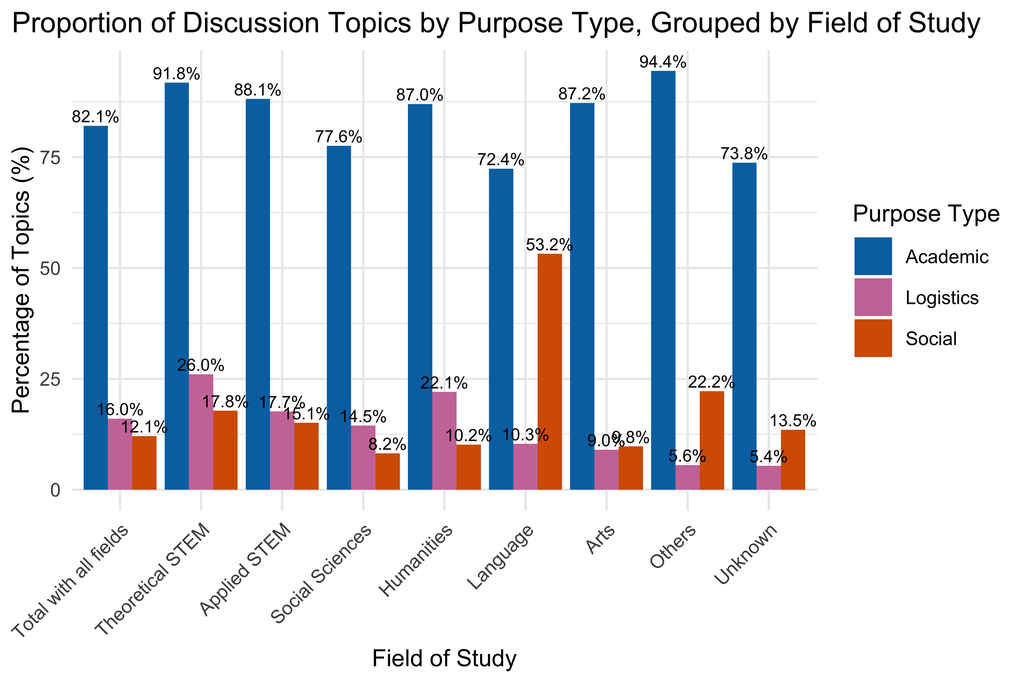

```r
# --- 1. Reshape the Data (Using the intermediate 'final_table' for convenience) ---
# Clean the percentage columns (remove '%' and convert to numeric)
plot_data_prep <- final_table_ordered %>%
  # Filter out the 'Total' row for field-level comparison plot
  # Remove the '%' character and convert to numeric
  mutate(
    across(ends_with("Percentage"), ~ as.numeric(gsub("%", "", .)))
  )

# Convert from wide to long format for plotting
plot_data_long <- plot_data_prep %>%
  pivot_longer(
    cols = ends_with("Percentage"),
    names_to = "Purpose_Type",
    values_to = "Percentage"
  ) %>%
  # Clean up the Purpose_Type names for the legend/axis
  mutate(
    Purpose_Type = gsub("_Percentage", "", Purpose_Type),
    # Reorder fields to be more academic (e.g., STEM, Social Sci, Hum, Arts/Lang)
    Field = fct_relevel(Field, "Total with all fields",
                        "Theoretical STEM", "Applied STEM", "Social Sciences",
                        "Humanities", "Language", "Arts", "Others", "Unknown")
  )

# --- 2. Create the Grouped Bar Chart ---
ggplot(plot_data_long, aes(x = Field, y = Percentage, fill = Purpose_Type)) +
  geom_bar(stat = "identity", position = "dodge") +
  # Add labels to the bars for exact percentage value
  geom_text(aes(label = sprintf("%.1f%%", Percentage)),
            position = position_dodge(width = 0.9),
            vjust = -0.3, size = 2.5) +
  scale_fill_manual(values = c("Academic" = "#0072B2", "Social" = "#D55E00", "Logistics" = "#CC79A7")) +
  labs(
    title = "Proportion of Discussion Topics by Purpose Type, Grouped by Field of Study",
    x = "Field of Study",
    y = "Percentage of Topics (%)",
    fill = "Purpose Type"
  ) +
  theme_minimal(base_size = 10) +
  theme(
    axis.text.x = element_text(angle = 45, hjust = 1),
    plot.title.position = "plot"
  )
```

# — 4. Regression — ## 4.1 RQ1 - overall change (topic level)

```r
# Initialize results dataframe
results_df <- data.frame(
  metric = character(),
  coef_GPT = numeric(),
  se_GPT = numeric(),
  t_value = numeric(),
  p_value = numeric(),
  sigsig = character(),
  stringsAsFactors = FALSE
)

# Loop through all metrics
for (metric in all_metrics) {
  # Build formula with course-level controls + fixed effects
  formula <- as.formula(
    paste0(metric, " ~ GPT_use + discussion_size + pct_international + pct_posts + course_type | discussion_topic_content_clean")
  )
  # Run regression with fixed effects
  model <- feols(formula, data = df_analysis_field)
  # Extract GPT coefficient info
  coef_summary <- summary(model)$coeftable
  gpt_row <- coef_summary["GPT_use", ]
  # Determine significance
  sig <- case_when(
    gpt_row["Pr(>|t|)"] <= 0.001 ~ "***",
    gpt_row["Pr(>|t|)"] <= 0.01  ~ "**",
    gpt_row["Pr(>|t|)"] <= 0.05  ~ "*",
    TRUE                         ~ ""
  )

  # Add to results dataframe
  results_df <- results_df %>%
    add_row(
      metric   = metric,
      coef_GPT = gpt_row["Estimate"],
      se_GPT   = gpt_row["Std. Error"],
      t_value  = gpt_row["t value"],
      p_value  = gpt_row["Pr(>|t|)"],
      sigsig   = sig
    )
}

# View summary table
results_df
```

```
##                 metric      coef_GPT      se_GPT     t_value      p_value
## 1       avg_similarity  0.0071345695 0.012862353  0.55468618 5.792464e-01
## 2   embedding_variance -0.0004597206 0.012500783 -0.03677535 9.706722e-01
## 3      semantic_spread -0.0485844277 0.023402998 -2.07599159 3.817657e-02
## 4            MRS_depth  0.0947692161 0.025907924  3.65792394 2.689503e-04
## 5       avg_word_count  0.0311344768 0.013929973  2.23507088 2.565600e-02
## 6         avg_analytic  0.1739144289 0.024718008  7.03594034 3.905403e-12
## 7  avg_informativeness  0.0054446573 0.027698550  0.19656832 8.442095e-01
## 8      percent_replied  0.0513754730 0.008865892  5.79473258 9.442316e-09
## 9            avg_depth  0.0043794416 0.003437259  1.27410858 2.029520e-01
## 10           max_depth  0.0266836813 0.016604079  1.60705576 1.083909e-01
## 11           avg_width  0.0032933809 0.003078169  1.06991554 2.849426e-01
## 12           max_width -0.0543230773 0.012907656 -4.20859357 2.825887e-05
##    sigsig
## 1
## 2
## 3       *
## 4     ***
## 5       *
## 6     ***
## 7
## 8     ***
## 9
## 10
## 11
## 12    ***
```

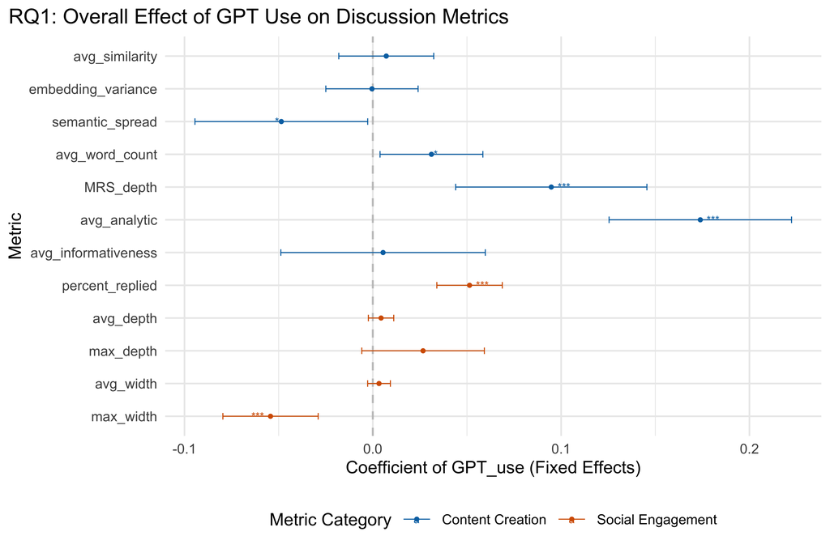

```r
# Define the custom order for the Y-axis metrics
custom_metric_order <- c(
  "avg_similarity",
  "embedding_variance",
  "semantic_spread",
  "avg_word_count",
  "MRS_depth",
  "avg_analytic",
  "avg_informativeness",
  "percent_replied",
  "avg_depth",
  "max_depth",
  "avg_width",
  "max_width"
)
# Add a category variable for coloring the metrics
results_df <- results_df %>%
  mutate(
    category = case_when(
      metric %in% content_metrics ~ "Content Creation",
      metric %in% social_metrics ~ "Social Engagement"),
    # Calculate lower and upper confidence bounds (using t-value * SE for ~95% CI)
    lower_ci = coef_GPT - (1.96 * se_GPT),
    upper_ci = coef_GPT + (1.96 * se_GPT),
    # Reorder metrics based on coefficient value within each category
    metric_ordered = factor(metric, levels = rev(custom_metric_order)))

# Create the Forest Plot
ggplot(results_df, aes(x = coef_GPT, y = metric_ordered, color = category)) +
  geom_vline(xintercept = 0, linetype = "dashed", alpha = 0.2) +
  # Plot confidence intervals
  geom_errorbarh(aes(xmin = lower_ci, xmax = upper_ci), height = 0.2, linewidth = 0.25) +
  # Plot the point estimate (coefficient)
  geom_point(size = 0.6) +
  # Add significance stars next to the points
  geom_text(aes(label = sigsig, x = coef_GPT),
            hjust = ifelse(results_df$coef_GPT > 0, -0.5, 1.5), # Adjust position based on coefficient sign
            vjust = 0.5, size = 2) +
  scale_color_manual(values = c("Content Creation" = "#0072B2", "Social Engagement" = "#D55E00")) +
  labs(
    title = "RQ1: Overall Effect of GPT Use on Discussion Metrics",
    x = "Coefficient of GPT_use (Fixed Effects)",
    y = "Metric",
    color = "Metric Category"
  ) +
  theme_minimal(base_size = 9) +
  theme(
    legend.position = "bottom",
    plot.title.position = "plot"
  )
```

### 4.2 RQ2 - subject matter (topic level)

```r
# Initialize a list to store results for each field
results_list <- list()
# Loop through the list of dataframes
for (field_name in names(field_subsets)) {
  rq2_df <- field_subsets[[field_name]]

  # Initialize a results dataframe for the current field
  results_field_df <- data.frame(
    metric = character(),
    coef_GPT = numeric(),
    se_GPT = numeric(),
    t_value = numeric(),
    p_value = numeric(),
    sigsig = character(),
    stringsAsFactors = FALSE
  )

  # Loop through all metrics for the current dataframe
  for (metric in all_metrics) {
    # Build formula with fixed effects
    formula <- as.formula(
      paste0(metric, " ~ GPT_use + discussion_size + pct_international + pct_posts | discussion_topic_content_clean")
    )
    # Run regression on the current dataframe
    model <- feols(formula, data = rq2_df)
    # Extract GPT coefficient info
    coef_summary <- summary(model)$coeftable

    # Check if 'GPT_use' exists in the model results
    if ("GPT_use" %in% rownames(coef_summary)) {
      gpt_row <- coef_summary["GPT_use", ]

      # Determine significance
      sig <- case_when(
        gpt_row["Pr(>|t|)"] <= 0.001 ~ "***",
        gpt_row["Pr(>|t|)"] <= 0.01 ~ "**",
        gpt_row["Pr(>|t|)"] <= 0.05 ~ "*",
        TRUE ~ ""
      )

      # Add to the current field's results dataframe
      results_field_df <- results_field_df %>%
        add_row(
          metric = metric,
          coef_GPT = gpt_row["Estimate"],
          se_GPT = gpt_row["Std. Error"],
          t_value = gpt_row["t value"],
          p_value = gpt_row["Pr(>|t|)"],
          sigsig = sig
        )
    }
  }
  # Store the complete results for the current field in the main list
  results_list[[field_name]] <- results_field_df
}
all_results <- bind_rows(results_list, .id = "field_name")
print(all_results)
```

```
##          field_name              metric      coef_GPT      se_GPT      t_value
## 1      Applied STEM      avg_similarity -0.0451781917 0.029415848 -1.535845280
## 2      Applied STEM  embedding_variance  0.0432741052 0.029320755  1.475886454
## 3      Applied STEM     semantic_spread -0.0202254652 0.045054367 -0.448912429
## 4      Applied STEM           MRS_depth  0.1603079561 0.069937815  2.292149901
## 5      Applied STEM      avg_word_count  0.1293759891 0.031304842  4.132778883
## 6      Applied STEM        avg_analytic  0.3938340107 0.065073421  6.052148545
## 7      Applied STEM avg_informativeness  0.1062934315 0.049587284  2.143562299
## 8      Applied STEM     percent_replied  0.0731801071 0.017189179  4.257335863
## 9      Applied STEM           avg_depth  0.0074884721 0.010000979  0.748773921
## 10     Applied STEM           max_depth  0.0540319267 0.028950341  1.866365801
## 11     Applied STEM           avg_width  0.0004911200 0.006928092  0.070888210
## 12     Applied STEM           max_width -0.0541088286 0.028071327 -1.927547946
## 13             Arts      avg_similarity  0.0229993517 0.037901749  0.606815048
## 14             Arts  embedding_variance -0.0248713903 0.037954599 -0.655293200
```

[output cut: 131 more lines]

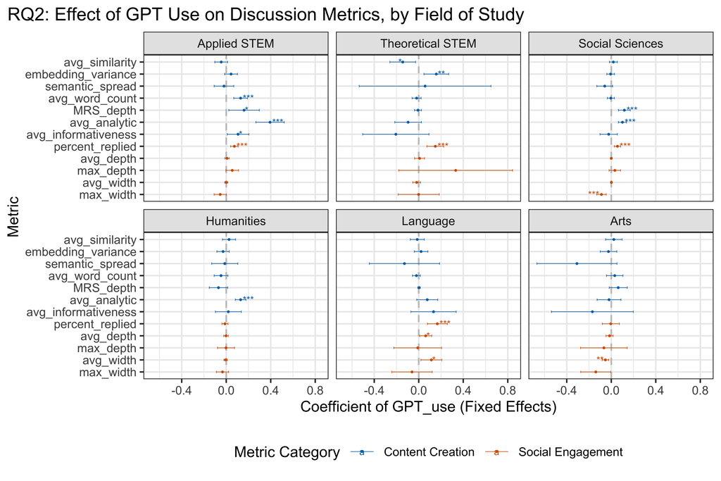

```r
# Prepare the data for plotting
all_results_plot <- all_results %>%
  mutate(
    category = case_when(
      metric %in% content_metrics ~ "Content Creation",
      metric %in% social_metrics ~ "Social Engagement"),
    lower_ci = coef_GPT - (1.96 * se_GPT),
    upper_ci = coef_GPT + (1.96 * se_GPT),
    metric = factor(metric, levels = rev(custom_metric_order)),
    # Ensure field is a factor in the desired order (optional)
    field_name = factor(field_name, levels = c("Applied STEM", "Theoretical STEM", "Social Sciences", "Humanities", "Language", "Arts"))
)
# Create the Grouped Forest Plot
ggplot(all_results_plot, aes(x = coef_GPT, y = metric, color = category)) +
  geom_vline(xintercept = 0, linetype = "dashed", alpha = 0.2) +

  # Plot confidence intervals and coefficient
  geom_errorbarh(aes(xmin = lower_ci, xmax = upper_ci), height = 0.2, linewidth = 0.15) +
  geom_point(size = 0.12) +

  # Add significance stars
  geom_text(aes(label = sigsig, x = coef_GPT),
            hjust = ifelse(all_results_plot$coef_GPT > 0, -0.2, 1.2),
            vjust = 0.5, size = 2) +

  scale_color_manual(values = c("Content Creation" = "#0072B2", "Social Engagement" = "#D55E00")) +

  facet_wrap(~ field_name, scales = "fixed", ncol = 3) + # Separate plot for each field

  labs(
    title = "RQ2: Effect of GPT Use on Discussion Metrics, by Field of Study",
    x = "Coefficient of GPT_use (Fixed Effects)",
    y = "Metric",
    color = "Metric Category"
  ) +
  theme_bw(base_size = 9) +
  theme(
    legend.position = "bottom",
    strip.background = element_rect(fill = "gray90"),
    plot.title.position = "plot"
  )
```

### 4.2.2 Control Question types for fields

```r
# Re-split the data frame based on 'field' from the dataframe that includes purpose types
field_subsets_purpose_all <- split(df_analysis_purposetype, df_analysis_purposetype$field)

# Will drop Unknown and Others field subset from this list
field_subsets_purpose <- field_subsets_purpose_all[names(field_subsets_purpose_all) != "Unknown" & names(field_subsets_purpose_all) != "Others"]

cat("✅ Field subsets re-created from df_analysis_purposetype to include 'academic', 'social', and 'logistics' controls.\n")
```

```
## ✅ Field subsets re-created from df_analysis_purposetype to include 'academic', 'social', and 'logistics' controls.
```

```r
cat("Subset Names (for iteration in regression):", names(field_subsets_purpose),"\n")
```

```
## Subset Names (for iteration in regression): Applied STEM Arts Humanities Language Social Sciences Theoretical STEM
```

```r
# Initialize a list to store results for each field
results_list_rq2_purpose <- list()
# Define the new control string
purpose_controls <- "academic + social + logistics"

# Loop through the list of dataframes
for (field_name in names(field_subsets_purpose)) {
  rq2_df_purpose <- field_subsets_purpose[[field_name]]

 # Initialize a results dataframe for the current field
 results_field_df_purpose <- data.frame(
 metric = character(),
     coef_GPT = numeric(),
     se_GPT = numeric(),
    t_value = numeric(),
     p_value = numeric(),
    sigsig = character(),
    stringsAsFactors = FALSE
     )

  # Loop through all metrics for the current dataframe
  for (metric in all_metrics) {
    # Build formula with fixed effects and purpose controls
    formula_purpose <- as.formula(
    paste0(metric, " ~ GPT_use + discussion_size + pct_international + pct_posts + ", purpose_controls, " | discussion_topic_content_clean")
    )
    # Run regression on the current dataframe
     # Use tryCatch to handle cases where a department subset might have issues (e.g., singular matrix due to low variation)
     model <- tryCatch({
     feols(formula_purpose, data = rq2_df_purpose)
     }, error = function(e) {
     cat(sprintf("Skipping %s for field %s due to error: %s\n", metric, field_name, e$message))
     return(NULL)
     })

     # Extract GPT coefficient info if the model ran successfully
     if (!is.null(model)) {
     coef_summary <- summary(model)$coeftable

    # Check if 'GPT_use' exists in the model results
    if ("GPT_use" %in% rownames(coef_summary)) {
    gpt_row <- coef_summary["GPT_use", ]

     # Determine significance
    sig <- case_when(
     gpt_row["Pr(>|t|)"] <= 0.001 ~ "***",
         gpt_row["Pr(>|t|)"] <= 0.01 ~ "**",
     gpt_row["Pr(>|t|)"] <= 0.05 ~ "*",
     TRUE ~ ""
    )

     # Add to the current field's results dataframe
 results_field_df_purpose <- results_field_df_purpose %>%
  add_row(
        metric = metric,
     coef_GPT = gpt_row["Estimate"],
    se_GPT = gpt_row["Std. Error"],
    t_value = gpt_row["t value"],
    p_value = gpt_row["Pr(>|t|)"],
    sigsig = sig
     )
     }
     }
  }
  # Store the complete results for the current field in the main list
  results_list_rq2_purpose[[field_name]] <- results_field_df_purpose
}

# Combine all RQ2 subset results into one dataframe
all_results_rq2_purpose <- bind_rows(results_list_rq2_purpose, .id = "field_name")
cat("\n✅ Regression for RQ2 (with purpose controls) complete.\n")
```

```
##
## ✅ Regression for RQ2 (with purpose controls) complete.
```

```r
print(all_results_rq2_purpose)
```

```
##          field_name              metric      coef_GPT      se_GPT     t_value
## 1      Applied STEM      avg_similarity -0.0454846884 0.029433444 -1.54534033
## 2      Applied STEM  embedding_variance  0.0436146896 0.029340548  1.48649879
## 3      Applied STEM     semantic_spread -0.0253397336 0.044543003 -0.56888247
## 4      Applied STEM           MRS_depth  0.1600073762 0.069692477  2.29590600
## 5      Applied STEM      avg_word_count  0.1294904330 0.031319316  4.13452299
## 6      Applied STEM        avg_analytic  0.3936253549 0.065236511  6.03381987
## 7      Applied STEM avg_informativeness  0.1049742953 0.049923297  2.10271160
## 8      Applied STEM     percent_replied  0.0722775480 0.017109339  4.22445008
## 9      Applied STEM           avg_depth  0.0074641530 0.010023006  0.74470207
## 10     Applied STEM           max_depth  0.0546341199 0.028972215  1.88574193
## 11     Applied STEM           avg_width  0.0003595085 0.006993856  0.05140348
## 12     Applied STEM           max_width -0.0529585003 0.028210620 -1.87725403
## 13             Arts      avg_similarity  0.0159436295 0.041205632  0.38692841
## 14             Arts  embedding_variance -0.0178917697 0.041207985 -0.43418211
```

[output cut: 131 more lines]

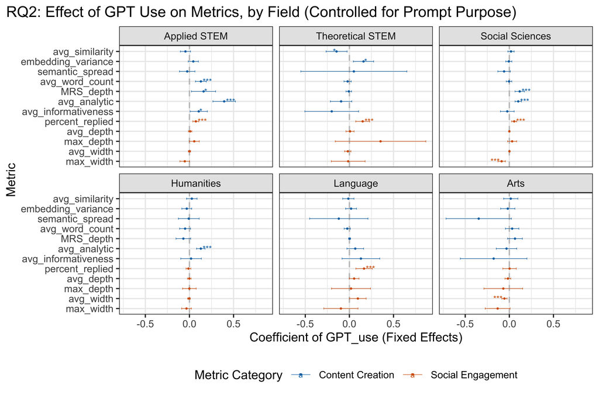

```r
# Prepare the data for plotting
all_results_rq2_purpose_plot <- all_results_rq2_purpose %>%
  mutate(
  category = case_when(
   metric %in% content_metrics ~ "Content Creation",
      metric %in% social_metrics ~ "Social Engagement"),
   lower_ci = coef_GPT - (1.96 * se_GPT),
   upper_ci = coef_GPT + (1.96 * se_GPT),
    metric = factor(metric, levels = rev(custom_metric_order)),
    # Ensure field is a factor in the desired order
    field_name = factor(field_name, levels = c("Applied STEM", "Theoretical STEM", "Social Sciences", "Humanities", "Language", "Arts"))
)
# Create the Grouped Forest Plot
ggplot(all_results_rq2_purpose_plot, aes(x = coef_GPT, y = metric, color = category)) +
    geom_vline(xintercept = 0, linetype = "dashed", alpha = 0.2) +

  # Plot confidence intervals and coefficient
  geom_errorbarh(aes(xmin = lower_ci, xmax = upper_ci), height = 0.2, linewidth = 0.15) +
  geom_point(size = 0.12) +

 # Add significance stars
   geom_text(aes(label = sigsig, x = coef_GPT),
          hjust = ifelse(all_results_rq2_purpose_plot$coef_GPT > 0, -0.2, 1.2),
         vjust = 0.5, size = 2) +

  scale_color_manual(values = c("Content Creation" = "#0072B2", "Social Engagement" = "#D55E00")) +

  facet_wrap(~ field_name, scales = "fixed", ncol = 3) + # Separate plot for each field

  labs(
  title = "RQ2: Effect of GPT Use on Metrics, by Field (Controlled for Prompt Purpose)",
 x = "Coefficient of GPT_use (Fixed Effects)",
  y = "Metric",
  color = "Metric Category"
  ) +
  theme_bw(base_size = 9) +
 theme(
 legend.position = "bottom",
 strip.background = element_rect(fill = "gray90"),
 plot.title.position = "plot"
 )
```

```r
# Initialize a list to store results for each RQ3 subset
results_list_rq3 <- list()

# Loop through the list of RQ3 subsets
for (subset_name in names(rq3_subsets_combined)) {
  current_df_rq3 <- rq3_subsets_combined[[subset_name]]

  # Initialize a results dataframe for the current subset
  results_subset_df <- data.frame(
    metric = character(),
    coef_GPT = numeric(),
    se_GPT = numeric(),
    t_value = numeric(),
    p_value = numeric(),
    sigsig = character(),
    stringsAsFactors = FALSE
  )

  # Loop through all metrics for the current dataframe
  for (metric in all_metrics) {
    # Build formula with fixed effects
    formula <- as.formula(
      paste0(metric, " ~ GPT_use + discussion_size + pct_international + pct_posts | discussion_topic_content_clean")
    )

    # Run regression on the current dataframe
    model <- feols(formula, data = current_df_rq3)

    # Extract GPT coefficient info
    coef_summary <- summary(model)$coeftable

    # Check if 'GPT_use' exists in the model results
    if ("GPT_use" %in% rownames(coef_summary)) {
      gpt_row <- coef_summary["GPT_use", ]

      # Determine significance
      sig <- case_when(
        gpt_row["Pr(>|t|)"] <= 0.001 ~ "***",
        gpt_row["Pr(>|t|)"] <= 0.01  ~ "**",
        gpt_row["Pr(>|t|)"] <= 0.05  ~ "*",
        TRUE                         ~ ""
      )

      # Add to the current subset's results dataframe
      results_subset_df <- results_subset_df %>%
        add_row(
          metric   = metric,
          coef_GPT = gpt_row["Estimate"],
          se_GPT   = gpt_row["Std. Error"],
          t_value  = gpt_row["t value"],
          p_value  = gpt_row["Pr(>|t|)"],
          sigsig   = sig
        )
    }
  }

  # Store the complete results for the current subset in the main list
  results_list_rq3[[subset_name]] <- results_subset_df
}

# Combine all RQ3 subset results into one dataframe
all_results_rq3 <- bind_rows(results_list_rq3, .id = "subset_name")
print(all_results_rq3)
```

```
##                   subset_name              metric      coef_GPT      se_GPT
## 1                  Conceptual      avg_similarity  2.531389e-03 0.015382959
## 2                  Conceptual  embedding_variance  3.130661e-03 0.015020269
## 3                  Conceptual     semantic_spread -6.285074e-02 0.031736046
## 4                  Conceptual           MRS_depth  1.269359e-01 0.038307578
## 5                  Conceptual      avg_word_count  4.747419e-02 0.021037129
## 6                  Conceptual        avg_analytic  1.895984e-01 0.033216501
## 7                  Conceptual avg_informativeness  4.217785e-02 0.036645558
## 8                  Conceptual     percent_replied  5.172237e-02 0.011068057
## 9                  Conceptual           avg_depth  4.902173e-03 0.003025158
## 10                 Conceptual           max_depth  3.996510e-02 0.020532454
## 11                 Conceptual           avg_width  5.518516e-03 0.003336772
## 12                 Conceptual           max_width -6.382930e-02 0.016198296
## 13                    Factual      avg_similarity -6.938187e-03 0.045745229
## 14                    Factual  embedding_variance  8.642255e-03 0.042389004
```

[output cut: 419 more lines]

```r
library(forcats)

rq3_plot_data <- all_results_rq3 %>%
  mutate(
    # Create the top-level grouping variable for faceting or filtering
    framework = case_when(
      subset_name %in% c("Factual", "Conceptual", "Procedural", "Metacognitive") ~ "Knowledge Type",
      subset_name %in% c("Remember", "Understand", "Analyze", "Evaluate", "Apply", "Create") ~ "Cognitive Process",
      subset_name %in% c("academic_purpose", "social_purpose", "logistics_purpose") ~ "Purpose Type",
      TRUE ~ "Academic Type" # Catches the remaining 5 academic types
    ),

    # Define metric category for color coding
    category = case_when(
      metric %in% content_metrics ~ "Content Creation",
      TRUE ~ "Social Engagement"
    ),

    # Calculate confidence bounds (95% CI)
    lower_ci = coef_GPT - (1.96 * se_GPT),
    upper_ci = coef_GPT + (1.96 * se_GPT)
  )
```

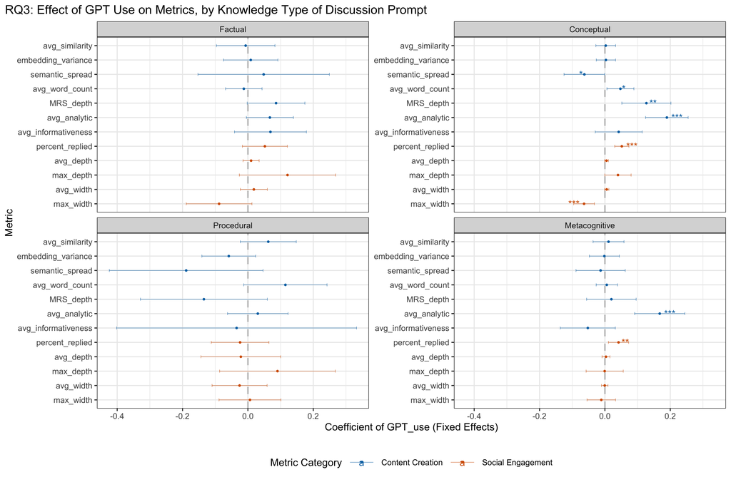

```r
# Filter data for Knowledge Types
knowledge_data <- rq3_plot_data %>%
  filter(framework == "Knowledge Type") %>%
  # Reorder subset_name for better presentation within the facet
  mutate(subset_name_ordered = fct_relevel(subset_name, "Factual", "Conceptual", "Procedural", "Metacognitive"),
        metric = factor(metric, levels = rev(custom_metric_order)))

ggplot(knowledge_data, aes(x = coef_GPT, y = metric, color = category)) +
  geom_vline(xintercept = 0, linetype = "dashed", alpha = 0.2, linewidth = 0.5) +
  geom_errorbarh(aes(xmin = lower_ci, xmax = upper_ci), height = 0.2, linewidth = 0.09) +
  geom_point(size = 0.06) +
  geom_text(aes(label = sigsig, x = coef_GPT),
            hjust = ifelse(knowledge_data$coef_GPT > 0, -0.4, 1.4),
            vjust = 0.5, size = 2) +
  facet_wrap(~ subset_name_ordered, scales = "free_y", ncol = 2) + # Facet by the 4 knowledge types
  scale_color_manual(values = c("Content Creation" = "#0072B2", "Social Engagement" = "#D55E00")) +
  labs(
    title = "RQ3: Effect of GPT Use on Metrics, by Knowledge Type of Discussion Prompt",
    x = "Coefficient of GPT_use (Fixed Effects)",
    y = "Metric",
    color = "Metric Category"
  ) +
  theme_bw(base_size = 6) +
  theme(
    legend.position = "bottom",
    strip.background = element_rect(fill = "gray85"),
    plot.title.position = "plot"
  )
```

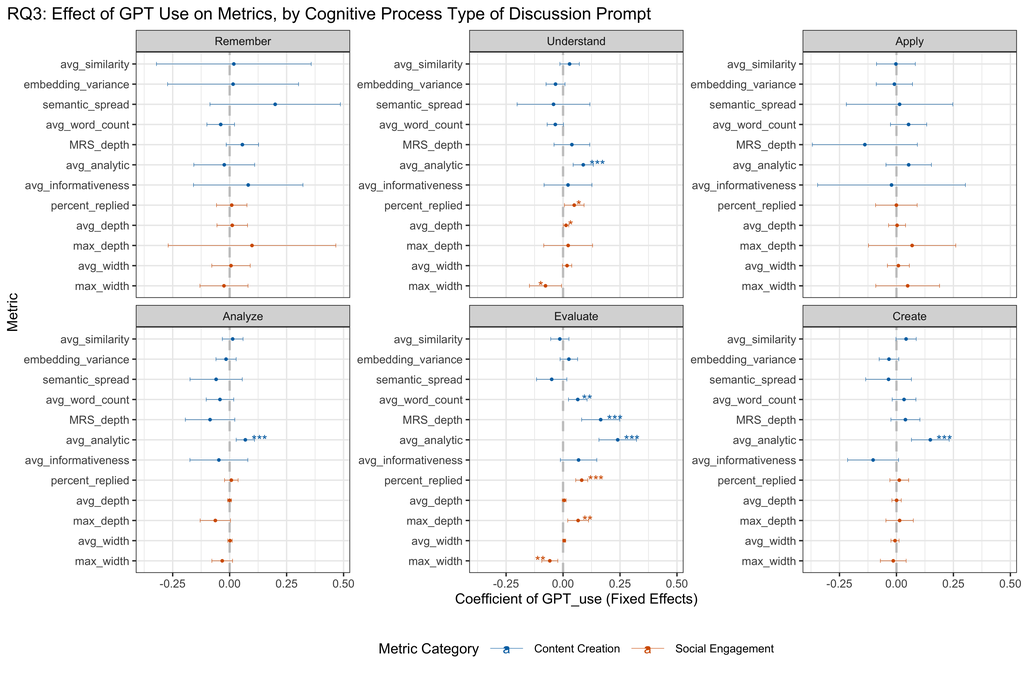

```r
# Filter data for Cognitive Process Types
cognitive_data <- rq3_plot_data %>%
  filter(framework == "Cognitive Process") %>%
  # Reorder subset_name for better presentation (e.g., Bloom's Taxonomy order)
  mutate(subset_name_ordered = fct_relevel(subset_name, "Remember", "Understand", "Apply", "Analyze", "Evaluate", "Create"),
                 metric = factor(metric, levels = rev(custom_metric_order)))

ggplot(cognitive_data, aes(x = coef_GPT, y = metric, color = category)) +
  geom_vline(xintercept = 0, linetype = "dashed", alpha = 0.2, linewidth = 0.5) +
  geom_errorbarh(aes(xmin = lower_ci, xmax = upper_ci), height = 0.2, linewidth = 0.09) +
  geom_point(size = 0.06) +
  geom_text(aes(label = sigsig, x = coef_GPT),
            hjust = ifelse(cognitive_data$coef_GPT > 0, -0.4, 1.4),
            vjust = 0.5, size = 2) +
  facet_wrap(~ subset_name_ordered, scales = "free_y", ncol = 3) + # Facet by the 6 cognitive types
  scale_color_manual(values = c("Content Creation" = "#0072B2", "Social Engagement" = "#D55E00")) +
  labs(
    title = "RQ3: Effect of GPT Use on Metrics, by Cognitive Process Type of Discussion Prompt",
    x = "Coefficient of GPT_use (Fixed Effects)",
    y = "Metric",
    color = "Metric Category"
  ) +
  theme_bw(base_size = 6) +
  theme(
    legend.position = "bottom",
    strip.background = element_rect(fill = "gray85"),
    plot.title.position = "plot"
  )
```

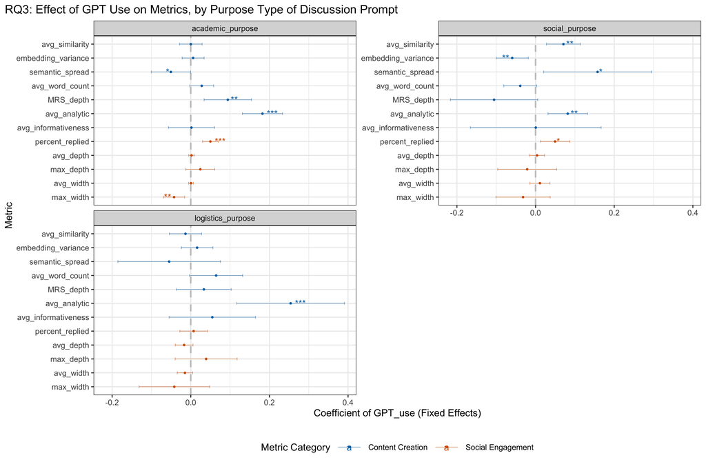

```r
# Filter data for Purpose Types
purpose_data <- rq3_plot_data %>%
  filter(framework == "Purpose Type") %>%
  # Reorder for better presentation
  mutate(subset_name_ordered = fct_relevel(subset_name, "academic_purpose", "social_purpose", "logistics_purpose"),
         metric = factor(metric, levels = rev(custom_metric_order)))

ggplot(purpose_data, aes(x = coef_GPT, y = metric, color = category)) +
  geom_vline(xintercept = 0, linetype = "dashed", alpha = 0.2, linewidth = 0.5) +
  geom_errorbarh(aes(xmin = lower_ci, xmax = upper_ci), height = 0.2, linewidth = 0.09) +
  geom_point(size = 0.06) +
  geom_text(aes(label = sigsig, x = coef_GPT),
            hjust = ifelse(purpose_data$coef_GPT > 0, -0.4, 1.4),
            vjust = 0.5, size = 2) +
  facet_wrap(~ subset_name_ordered, scales = "free_y", ncol = 2) + # Facet by the 3 purpose types
  scale_color_manual(values = c("Content Creation" = "#0072B2", "Social Engagement" = "#D55E00")) +
  labs(
    title = "RQ3: Effect of GPT Use on Metrics, by Purpose Type of Discussion Prompt",
    x = "Coefficient of GPT_use (Fixed Effects)",
    y = "Metric",
    color = "Metric Category"
  ) +
  theme_bw(base_size = 6) +
  theme(
    legend.position = "bottom",
    strip.background = element_rect(fill = "gray85"),
    plot.title.position = "plot"
  )
```

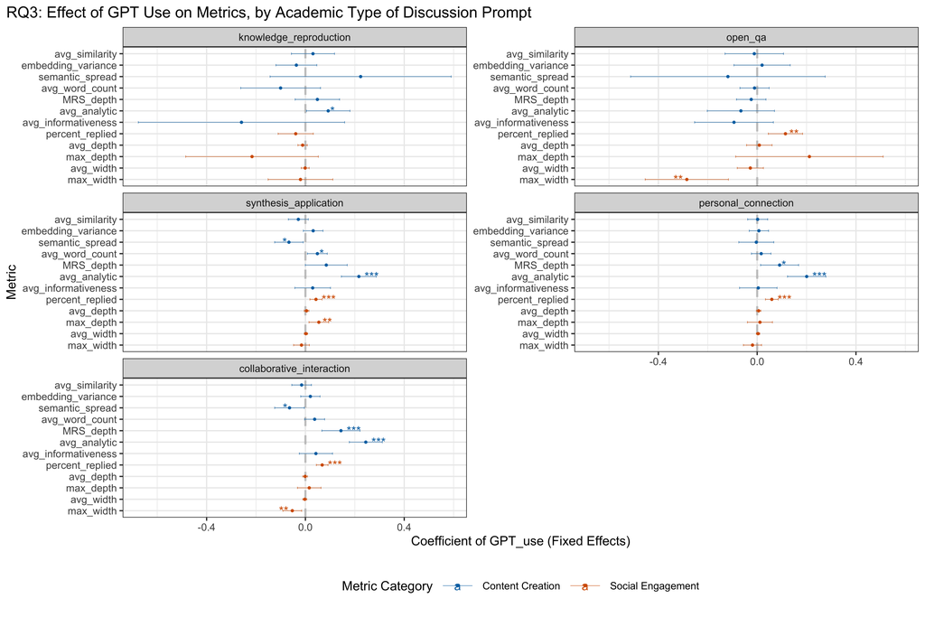

```r
# Filter data for Academic Types
academic_data <- rq3_plot_data %>%
  filter(framework == "Academic Type") %>%
  # Reorder for better presentation
  mutate(subset_name_ordered = fct_relevel(subset_name, "knowledge_reproduction", "open_qa", "synthesis_application", "personal_connection", "collaborative_interaction"),
         metric = factor(metric, levels = rev(custom_metric_order)))

ggplot(academic_data, aes(x = coef_GPT, y = metric, color = category)) +
  geom_vline(xintercept = 0, linetype = "dashed", alpha = 0.2, linewidth = 0.5) +
  geom_errorbarh(aes(xmin = lower_ci, xmax = upper_ci), height = 0.2, linewidth = 0.09) +
  geom_point(size = 0.06) +
  geom_text(aes(label = sigsig, x = coef_GPT),
            hjust = ifelse(academic_data$coef_GPT > 0, -0.4, 1.4),
            vjust = 0.5, size = 2) +
  facet_wrap(~ subset_name_ordered, scales = "free_y", ncol = 2) + # Facet by the 5 academic types
  scale_color_manual(values = c("Content Creation" = "#0072B2", "Social Engagement" = "#D55E00")) +
  labs(
    title = "RQ3: Effect of GPT Use on Metrics, by Academic Type of Discussion Prompt",
    x = "Coefficient of GPT_use (Fixed Effects)",
    y = "Metric",
    color = "Metric Category"
  ) +
  theme_bw(base_size = 6) +
  theme(
    legend.position = "bottom",
    strip.background = element_rect(fill = "gray85"),
    plot.title.position = "plot"
  )
```